# 2019-2020 NFL Season Data Manipulation & Betting Predictions

## Introduction

I will be analyzing 2019-2020 NFL Data in order to compare teams' performance as well as determine whether certain factors, such as game location (home vs away), stadium roof type (fixed, open, or retractable), etc. impacts a team's performance. After collecting this data, I will merge it with NFL betting odds data for the upcoming week's games in order to predictively model the best bets against the spread and over/under lines.

## Dimension 1: Data Gathering

I create the following dataframes:

- **stadiums** : I use pandas to read NFL stadium data from Wikipedia into a table. I will use this data to later determine if games were played under fixed, open, or retractable roofs and whether that impacts NFL game results.
- **result**: I do a get request to cbssports.com and use BeautifulSoup to scrape all the NFL team names as well as the URLs to their game results. I then loop through a list of the urls and use pandas to read the game results into an individual table for each team. I then concatenate these tables using the concat function and set the index to be the team name.
- **upcoming_week** : I use pandas to read the current week's upcoming NFL games from CBS. I put games that have yet to happen into a dataframe. For example, if it is a Wednesday the table will contain the upcoming Thursday night, Sunday, and Monday night games. However, if it is a Monday morning, the table will only contain the Monday night game that has not yet occurred.

  ```
    NOTE: CBS link must be updated to include the current NFL week. EX: This week (12/10/19) is WEEK 15.
    Therefore, the link I am using is https://www.cbssports.com/nfl/schedule/2019/regular/15/ with 15
    included at the end of this URL. From 12/17-12/23, the link should
    be https://www.cbssports.com/nfl/schedule/2019/regular/16/.
  ```

- **bets**: I use pandas to read betting odds data for the week from Odds Shark. I collect of all of the teams favored to win, the spread, spread price, O/U, and O/U price into a dataframe called bets that I later merge with result by matching based on if the "Team Favored To Win" in bets is equal to the 'Home' or 'Away' team in result.

## Dimension 2: Data Cleaning

**result** table columns added based on cleaning 'Result' and 'OPP' columns:

- **Outcome** (W, L, or T)
- **Offense** (points scored)
- **Defense** (points allowed)
- **Location** (Home or Away)

**result** table columns cleaned:

- **OPP** (clean up opponent name in "OPP" column to have all team names be written consistently)

**upcoming_week** table columns cleaned:

- **Away** (clean up team names in "Away" column to have all team names be written consistently)
- **Home** (clean up team names in "Home" column to have all team names be written consistently)

**bets** table columns cleaned:

- **Team Favored to Win** (clean up team names in "Team Favored to Win" column to have all team names be written consistently)
- **O/U** (display numeric value)

## Dimension 3: Data Manipulation

**averages** dataframe creation from result dataframe:

- I create an averages dataframe by using group by and data aggregation to include average offense and defensive scores by team. After applying my two statistical functions calc_off_adjusted and calc_def_adjusted to the result dataframe (see Dimension 4: Data Reporting), I update the averages dataframe to include offensive adjusted scores and defensive adjusted scores by team using data aggregation.

**result** dataframe updated to include information from stadiums dataframe:

**upcoming_week_predictions** dataframe created by merging upcoming_week with bets:

- I perform two merges and append the dataframes together since the bets dataframe only contains one team name ("Team Favored to Win") and it is unclear weather the team favored is playing at home or away:

  1) merge based off upcoming_week['Home'] column and bets['Team']

  2) merge based off upcoming_week['Away'] column and bets['Team']
- This dataframe allows the viewer to make betting predictions for the week based on betting odds and predicted numbers.

**result_pivot** created from a pivot table of the result dataframe:

- I analyze how many points teams score on average on offense and allow on average on defense based on whether they are playing in an indoor or outdoor stadium (i.e., if roof is fixed, open, or retractable).

**records** created from a pivot table from result dataframe:

- I create a pivot table depicting how many wins, losses, and ties each NFL team has had.

**scores_by_location** created from a pivot table from result dataframe:

- I create a pivot table depicting average team scores by location (home or away).

## Dimension 4: Data Reporting

I apply multiple functions to my dataframes in order to analyze current team statistics and predict accurate future team statistics and game results.

I apply the following functions to my **result** dataframe in order to demonstrate findings in NFL 2019 season results:

- **calc_off_adjusted**: calculate a team's offensive adjusted score ("Offense_Adj") for each game of the 2019 season by dividing how many points the team scored on offense by their opponent's average defensive points allowed
  - If > 1: team played well on offense
  - If < 1: team played badly on offense
- **calc_def_adjusted**: calculate a team's defensive adjusted score ("Defense_Adj") for each game of the 2019 season by dividing how many points the team allowed on defense by the amount of points their opponent scores on average on offense
  - If > 1: team played badly on defense
  - If < 1: team played well on defense

I apply the following functions to my **upcoming_week** dataframe in order to predict the next week's NFL games results:

- **predict_home**: calculate the home team's predicted points scored

  1) calculate the average amount of points the home team will score on offense by averaging the amount of points the home team scores on average on offense with the average amount of points the away team's defense allows

  2) calculate the home team's average adjusted amount of points on offense by averaging the home team's average amount of points adjusted on offense with the average adjusted amount of points the away team's defense allows

  3) return the product of the average and average adjusted calculations as the home team's final predicted offensive score
- **predict_away**: calculate the away team's predicted points scored

  1) calculate the average amount of points the away team will score on offense by averaging the amount of points the away team scores on average on offense with the average amount of points the home team's defense allows

  2) calculate the away team's average adjusted amount of points on offense by averaging the away team's average amount of points adjusted on offense with the average adjusted amount of points the home team's defense allows

  3) return the product of the average and average adjusted calculations as the away team's final predicted offensive score
- **predict_total_points**: return the sum of the predicted home and away total points scored on offense predictions
- **predict_difference**: return the difference of the predicted home and away total points scored on offense predictions

I create the following data visualizations to clearly depict team performance and smart betting decisions:

- **Vertical bar plots** - analyze data from upcoming_week_predictions table by comparing the absolute value of the predicted difference in teams' scores ("Predicted_Difference") to the absolute value of the spread ("Spread") as well as the teams' predicted total combined score ("Predicted_Total") to the O/U ("O/U")
  - imported seaborn to create better looking bar plots using seaborn styles
- **Pivot table vertical bar plot** - bar chart of records pivot table
  - imported seaborn to create better looking bar plots using seaborn styles
- **Pivot table line plot** - scores_by_location pivot table
  - imported mathplotlib.pyplot as plt
  - plot initially repeated colors so could not differentiate teams from each other -- used seaborn color palette to import 32 unique colors for every individual NFL team
  - use savefig to save line plot as a png image

## Goal

This notebook demonstrates how to create a dataframe that analyzes 2019-2020 NFL season data to date in order to predictively model the upcoming week’s NFL games’ results and compare predictive game outcomes with betting odds.

**Run this notebook to determine which NFL spreads and Over/Under bets are smart to gamble on for the week.**

## 1. Create Dataframes

```python
import pandas as pd
import requests
from bs4 import BeautifulSoup
import re
import numpy as np
%matplotlib inline
import matplotlib.pyplot as plt
import seaborn as sns
```

### Data gathering: stadiums dataframe

```python
# creating stadiums dataframe from Wikipedia
stadiums = pd.read_html("https://en.wikipedia.org/wiki/List_of_current_National_Football_League_stadiums")
stadiums = stadiums[1]

# fixing stadiums to have two individual rows for the New York Giants and New York Jets since both teams
# play in the Metlife Stadium and I will later merge off of 'Team(s)'
stadiums = stadiums.append({'Image' : None , 'Name' : "MetLife Stadium", 'Capacity': 82500, 'Location': 'East Rutherford, New Jersey', 'Surface': 'UBU Sports Speed Series S5-M Synthetic Turf[33]', 'Roof type' : 'Open', 'Team(s)': 'New York Giants', 'Opened': 2010, 'Ref(s)' : '[34]' } , ignore_index=True)
stadiums = stadiums.append({'Image' : None , 'Name' : "MetLife Stadium", 'Capacity': 82500, 'Location': 'East Rutherford, New Jersey', 'Surface': 'UBU Sports Speed Series S5-M Synthetic Turf[33]', 'Roof type' : 'Open', 'Team(s)': 'New York Jets', 'Opened': 2010, 'Ref(s)' : '[34]' } , ignore_index=True)

# stadiums dataframe
stadiums
```

|  | Image | Name | Capacity | Location | Surface | Roof type | Team(s) | Opened | Ref(s) |
| --- | --- | --- | --- | --- | --- | --- | --- | --- | --- |
| 0 | NaN | Arrowhead Stadium | 76416 | Kansas City, Missouri | Bermuda grass | Open | Kansas City Chiefs | 1972 | [4] |
| 1 | NaN | AT&T Stadium | 80000 | Arlington, Texas | Hellas Matrix Turf | Retractable | Dallas Cowboys | 2009 | [5][6] |
| 2 | NaN | Bank of America Stadium | 75523 | Charlotte, North Carolina | Bermuda grass | Open | Carolina Panthers | 1996 | [7] |
| 3 | NaN | CenturyLink Field | 69000 | Seattle, Washington | FieldTurf Revolution 360[8] | Open | Seattle Seahawks | 2002 | [9] |
| 4 | NaN | Dignity Health Sports Park | 27000 | Carson, California | Bermuda grass | Open | Los Angeles Chargers | 2003 | [10] |
| 5 | NaN | Empower Field at Mile High | 76125 | Denver, Colorado | Kentucky bluegrass | Open | Denver Broncos | 2001 | [11] |
| 6 | NaN | FedExField | 82000 | Landover, Maryland | Bermuda grass | Open | Washington Redskins | 1997 | [12] |
| 7 | NaN | FirstEnergy Stadium | 67895 | Cleveland, Ohio | Kentucky bluegrass | Open | Cleveland Browns | 1999 | [13][14] |
| 8 | NaN | Ford Field | 65000 | Detroit, Michigan | FieldTurf Classic HD[15] | Fixed | Detroit Lions | 2002 | [16] |
| 9 | NaN | Gillette Stadium | 66829 | Foxborough, Massachusetts | FieldTurf CORE[17] | Open | New England Patriots | 2002 | [18] |
| 10 | NaN | Hard Rock Stadium | 65326 | Miami Gardens, Florida | Platinum TE Paspalum | Open | Miami Dolphins | 1987 | [19] |
| 11 | NaN | Heinz Field | 68400 | Pittsburgh, Pennsylvania | Kentucky bluegrass | Open | Pittsburgh Steelers | 2001 | [20] |
| 12 | NaN | Lambeau Field | 81441 | Green Bay, Wisconsin | Desso GrassMaster[21] | Open | Green Bay Packers | 1957 | [22] |
| 13 | NaN | Levi's Stadium | 68500 | Santa Clara, California | Bermuda grass / Perennial Ryegrass mixture | Open | San Francisco 49ers | 2014 | [23] |
| 14 | NaN | Lincoln Financial Field | 69596 | Philadelphia, Pennsylvania | Desso GrassMaster[24] | Open | Philadelphia Eagles | 2003 | [25] |
| 15 | NaN | Los Angeles Memorial Coliseum | 78500 | Los Angeles, California | Bermuda grass | Open | Los Angeles Rams | 1923 | [26] |
| 16 | NaN | Lucas Oil Stadium | 67000 | Indianapolis, Indiana | Shaw Sports Momentum Pro | Retractable | Indianapolis Colts | 2008 | [27] |
| 17 | NaN | M&T Bank Stadium | 71008 | Baltimore, Maryland | Bermuda grass | Open | Baltimore Ravens | 1998 | [28] |
| 18 | NaN | Mercedes-Benz Superdome | 73208 | New Orleans, Louisiana | FieldTurf Revolution 360[29] | Fixed | New Orleans Saints | 1975 | [30] |
| 19 | NaN | Mercedes-Benz Stadium | 71000 | Atlanta, Georgia | FieldTurf Revolution[31] | Retractable | Atlanta Falcons | 2017 | [32] |
| 20 | NaN | MetLife Stadium | 82500 | East Rutherford, New Jersey | UBU Sports Speed Series S5-M Synthetic Turf[33] | Open | New York GiantsNew York Jets | 2010 | [34] |
| 21 | NaN | New Era Field | 71608 | Orchard Park, New York | A-Turf Titan 50[35] | Open | Buffalo Bills | 1973 | [35] |
| 22 | NaN | Nissan Stadium | 69143 | Nashville, Tennessee | Bermuda grass | Open | Tennessee Titans | 1999 | [36] |
| 23 | NaN | NRG Stadium | 72220 | Houston, Texas | Hellas Matrix Turf[37] | Retractable | Houston Texans | 2002 | [38] |
| 24 | NaN | Paul Brown Stadium | 65515 | Cincinnati, Ohio | UBU Speed Series S5-M Synthetic Turf | Open | Cincinnati Bengals | 2000 | [39] |
| 25 | NaN | Raymond James Stadium | 65890 | Tampa, Florida | Bermuda grass | Open | Tampa Bay Buccaneers | 1998 | [40] |
| 26 | NaN | RingCentral Coliseum | 56057 | Oakland, California | Bermuda grass | Open | Oakland Raiders | 1966 | [41] |
| 27 | NaN | Soldier Field | 61500 | Chicago, Illinois | Kentucky bluegrass | Open | Chicago Bears | 1924[nb 1] | [42] |
| 28 | NaN | State Farm Stadium | 63400 | Glendale, Arizona | Bermuda grass | Retractable | Arizona Cardinals | 2006 | [43] |
| 29 | NaN | TIAA Bank Field | 69132 | Jacksonville, Florida | Bermuda grass | Open | Jacksonville Jaguars | 1995 | [44] |
| 30 | NaN | U.S. Bank Stadium | 66655 | Minneapolis, Minnesota | UBU Speed Series S5-M Synthetic Turf[45] | Fixed | Minnesota Vikings | 2016 | [46] |
| 31 | None | MetLife Stadium | 82500 | East Rutherford, New Jersey | UBU Sports Speed Series S5-M Synthetic Turf[33] | Open | New York Giants | 2010 | [34] |
| 32 | None | MetLife Stadium | 82500 | East Rutherford, New Jersey | UBU Sports Speed Series S5-M Synthetic Turf[33] | Open | New York Jets | 2010 | [34] |

### Data gathering: result dataframe

```python
# building result dataframe to compile all results from 2019-2020 NFL Season so far
html = requests.get("https://www.cbssports.com/nfl/teams/").text
soup = BeautifulSoup(html, 'html.parser')
soup

teams =  soup.find_all(class_='TeamName')
teamNames = []
urls = []
for t in teams:
    urls.append(t.a['href'])
    teamNames.append(t.text)

count = 0
l_tables = []
for u in urls:
    start = "https://www.cbssports.com"
    end = "schedule/"
    tables = pd.read_html(start + u + end)
    table = tables[1]
    table['team'] = teamNames[count]
    l_tables.append(table)
    count = count+1

result = pd.concat(l_tables)
result.set_index('team').head(20)
```

| team | Wk | Date | OPP | Result | Record |
| --- | --- | --- | --- | --- | --- |
| Buffalo Bills | 1 | Sep 8, 2019 | @ N.Y. Jets | W 17-16 | 1-0 |
| Buffalo Bills | 2 | Sep 15, 2019 | @ N.Y. Giants | W 28-14 | 2-0 |
| Buffalo Bills | 3 | Sep 22, 2019 | vs Cincinnati | W 21-17 | 3-0 |
| Buffalo Bills | 4 | Sep 29, 2019 | vs New England | L 16-10 | 3-1 |
| Buffalo Bills | 5 | Oct 6, 2019 | @ Tennessee | W 14-7 | 4-1 |
| Buffalo Bills | 6 | — | BYE | — | — |
| Buffalo Bills | 7 | Oct 20, 2019 | vs Miami | W 31-21 | 5-1 |
| Buffalo Bills | 8 | Oct 27, 2019 | vs Philadelphia | L 31-13 | 5-2 |
| Buffalo Bills | 9 | Nov 3, 2019 | vs Washington | W 24-9 | 6-2 |
| Buffalo Bills | 10 | Nov 10, 2019 | @ Cleveland | L 19-16 | 6-3 |
| Buffalo Bills | 11 | Nov 17, 2019 | @ Miami | W 37-20 | 7-3 |
| Buffalo Bills | 12 | Nov 24, 2019 | vs Denver | W 20-3 | 8-3 |
| Buffalo Bills | 13 | Nov 28, 2019 | @ Dallas | W 26-15 | 9-3 |
| Buffalo Bills | 14 | Dec 8, 2019 | vs Baltimore | L 24-17 | 9-4 |
| Miami Dolphins | 1 | Sep 8, 2019 | vs Baltimore | L 59-10 | 0-1 |
| Miami Dolphins | 2 | Sep 15, 2019 | vs New England | L 43-0 | 0-2 |
| Miami Dolphins | 3 | Sep 22, 2019 | @ Dallas | L 31-6 | 0-3 |
| Miami Dolphins | 4 | Sep 29, 2019 | vs L.A. Chargers | L 30-10 | 0-4 |
| Miami Dolphins | 5 | — | BYE | — | — |
| Miami Dolphins | 6 | Oct 13, 2019 | vs Washington | L 17-16 | 0-5 |

### Data gathering: upcoming_week dataframe

**IMPORTANT NOTE: CBS link must be updated to include the current NFL week. EX: This week (12/10/19) is WEEK 15. Therefore, the link I am using is https://www.cbssports.com/nfl/schedule/2019/regular/15/ with 15 included at the end of this URL. From 12/17 - 12/23, the link should be https://www.cbssports.com/nfl/schedule/2019/regular/16/.**

```python
# create upcoming_week dataframe - there are Thursday, Sunday, and Monday night games but I just
# want to look at the week's games that have not yet occured in order to make predictions

# !!!!!!!!!!!!!!!!!!!!!!!!!!!!!!!!!!!!!!!!!!!!!!!!!!!!!!!!!!!!!!!!!!!!!!!!!!!!!!!!!!!!!!!!!!!!!!!!!!!!!!!!!!!!!
# IMPORTANT NOTE: CBS link must be updated to include the current NFL week. EX: This week (12/10/19) is WEEK 15.
# Therefore, the link I am using is https://www.cbssports.com/nfl/schedule/2019/regular/15/ with 15
# included at the end of this URL. From 12/17 - 12/23, the link should
# be https://www.cbssports.com/nfl/schedule/2019/regular/16/.
# !!!!!!!!!!!!!!!!!!!!!!!!!!!!!!!!!!!!!!!!!!!!!!!!!!!!!!!!!!!!!!!!!!!!!!!!!!!!!!!!!!!!!!!!!!!!!!!!!!!!!!!!!!!!!

nfl_games = pd.read_html("https://www.cbssports.com/nfl/schedule/2019/regular/15/")
next_games = []
for n in nfl_games:
    if 'Result' in n.columns:
        pass
    else:
        next_games.append(n)

upcoming_week = pd.concat(next_games)
upcoming_week
```

|  | Away | Home | Time | TV | Venue | Buy Tickets |
| --- | --- | --- | --- | --- | --- | --- |
| 0 | N.Y. Jets | Baltimore | 8:20 pm | NFLN | M&T Bank Stadium | Tickets Starting at $48.00 |
| 0 | Miami | N.Y. Giants | 1:00 pm | NaN | MetLife Stadium | Tickets Starting at $24.29 |
| 1 | Houston | Tennessee | 1:00 pm | NaN | Nissan Stadium | Tickets Starting at $55.48 |
| 2 | New England | Cincinnati | 1:00 pm | NaN | Paul Brown Stadium | Tickets Starting at $51.03 |
| 3 | Seattle | Carolina | 1:00 pm | FOX | Bank of America Stadium | Tickets Starting at $40.00 |
| 4 | Tampa Bay | Detroit | 1:00 pm | FOX | Ford Field | Tickets Starting at $32.00 |
| 5 | Denver | Kansas City | 1:00 pm | NaN | Arrowhead Stadium | Tickets Starting at $48.00 |
| 6 | Philadelphia | Washington | 1:00 pm | FOX | FedEx Field | Tickets Starting at $40.00 |
| 7 | Chicago | Green Bay | 1:00 pm | FOX | Lambeau Field | Tickets Starting at $121.00 |
| 8 | Jacksonville | Oakland | 4:05 pm | NaN | RingCentral Coliseum | Tickets Starting at $152.52 |
| 9 | Cleveland | Arizona | 4:05 pm | NaN | State Farm Stadium | Tickets Starting at $60.00 |
| 10 | Minnesota | L.A. Chargers | 4:05 pm | NaN | Dignity Health Sports Park | Tickets Starting at $209.95 |
| 11 | Atlanta | San Francisco | 4:25 pm | FOX | Levi's Stadium | Tickets Starting at $95.00 |
| 12 | L.A. Rams | Dallas | 4:25 pm | FOX | AT&T Stadium | Tickets Starting at $39.00 |
| 13 | Buffalo | Pittsburgh | 8:20 pm | NBC | Heinz Field | Tickets Starting at $94.00 |
| 0 | Indianapolis | New Orleans | 8:15 pm | ESPN | Mercedes-Benz Superdome | Tickets Starting at $73.99 |

### Data gathering: bets dataframe

```python
# bets dataframe: betting_odds from Odds Shark
betting_odds = pd.read_html("https://www.oddsshark.com/nfl/consensus-picks")
odds = pd.DataFrame()
col = ['Unnamed: 0', 'ATS Consensus', 'ATS Consensus.1','Spread','Price','O/U Consensus','O/U Consensus.1','Price.1']
odds = odds.reindex(columns=col)
all_odds = []

for b in betting_odds:
    if (b['Spread'][0] == 'Ev') == True:
        odds = (b.iloc[[0]])
        all_odds.append(odds)
    else:
        b['Spread'] = pd.to_numeric(b['Spread'])
        if b['Spread'][0] < 0:
            odds = (b.iloc[[0]])
            all_odds.append(odds)
        else:
            odds = (b.iloc[[1]])
            all_odds.append(odds)

bets = pd.concat(all_odds)
bets
```

|  | Unnamed: 0 | ATS Consensus | ATS Consensus.1 | Spread | Price | O/U Consensus | O/U Consensus.1 | Price.1 |
| --- | --- | --- | --- | --- | --- | --- | --- | --- |
| 1 | NaN | BAL Baltimore | 54% | -17.0 | -110 | O/U44 | 48% | -110 |
| 1 | NaN | GB Green Bay | 51% | -4.0 | -110 | O/U40.5 | 37% | -110 |
| 1 | NaN | KC Kansas City | 53% | -10.0 | -105 | O/U45 | 32% | -110 |
| 1 | NaN | TEN Tennessee | 46% | -3.0 | -120 | O/U51 | 37% | -110 |
| 0 | Matchup | SEA Seattle | 69% | -6.5 | -110 | O/U49 | 52% | -110 |
| 0 | Matchup | NE New England | 64% | -10.0 | -110 | O/U41.5 | 60% | -115 |
| 0 | Matchup | TB Tampa Bay | 56% | -3.5 | -110 | O/U46 | 68% | -110 |
| 1 | NaN | NYG NY Giants | 46% | -3.5 | -105 | O/U46.5 | 56% | -110 |
| 0 | Matchup | PHI Philadelphia | 57% | -5.0 | -110 | O/U39 | 53% | -110 |
| 1 | NaN | OAK Oakland | 59% | -6.5 | -110 | O/U45.5 | 35% | -110 |
| 0 | Matchup | CLE Cleveland | 60% | -2.5 | -110 | O/U49 | 67% | -110 |
| 0 | Matchup | MIN Minnesota | 61% | -2.5 | -110 | O/U45.5 | 62% | -110 |
| 1 | NaN | SF San Francisco | 55% | -10.5 | -110 | O/U48 | 30% | -110 |
| 0 | Matchup | LAR LA Rams | 66% | -1.5 | -110 | O/U49 | 55% | -110 |
| 1 | NaN | PIT Pittsburgh | 34% | -1.5 | -110 | O/U35.5 | 37% | -110 |
| 1 | NaN | NO New Orleans | 57% | -9.0 | -110 | O/U46.5 | 36% | -110 |

## 2. Clean Dataframes

### result dataframe

I write my own functions and use .apply to apply them to the dataframe as well as use .str functions to clean the dataframe.

The 'Result" column of result contains a string like "W 17-16" which must be separated into "Outcome" (W, L, or T), "Offense" (offensive points scored), and "Defense" (defensive points allowed).

```python
# Outcome column
result['Outcome'] = result['Result'].str.extract(r'(\w)')
result.set_index('team').head(20)
```

| team | Wk | Date | OPP | Result | Record | Outcome |
| --- | --- | --- | --- | --- | --- | --- |
| Buffalo Bills | 1 | Sep 8, 2019 | @ N.Y. Jets | W 17-16 | 1-0 | W |
| Buffalo Bills | 2 | Sep 15, 2019 | @ N.Y. Giants | W 28-14 | 2-0 | W |
| Buffalo Bills | 3 | Sep 22, 2019 | vs Cincinnati | W 21-17 | 3-0 | W |
| Buffalo Bills | 4 | Sep 29, 2019 | vs New England | L 16-10 | 3-1 | L |
| Buffalo Bills | 5 | Oct 6, 2019 | @ Tennessee | W 14-7 | 4-1 | W |
| Buffalo Bills | 6 | — | BYE | — | — | NaN |
| Buffalo Bills | 7 | Oct 20, 2019 | vs Miami | W 31-21 | 5-1 | W |
| Buffalo Bills | 8 | Oct 27, 2019 | vs Philadelphia | L 31-13 | 5-2 | L |
| Buffalo Bills | 9 | Nov 3, 2019 | vs Washington | W 24-9 | 6-2 | W |
| Buffalo Bills | 10 | Nov 10, 2019 | @ Cleveland | L 19-16 | 6-3 | L |
| Buffalo Bills | 11 | Nov 17, 2019 | @ Miami | W 37-20 | 7-3 | W |
| Buffalo Bills | 12 | Nov 24, 2019 | vs Denver | W 20-3 | 8-3 | W |
| Buffalo Bills | 13 | Nov 28, 2019 | @ Dallas | W 26-15 | 9-3 | W |
| Buffalo Bills | 14 | Dec 8, 2019 | vs Baltimore | L 24-17 | 9-4 | L |
| Miami Dolphins | 1 | Sep 8, 2019 | vs Baltimore | L 59-10 | 0-1 | L |
| Miami Dolphins | 2 | Sep 15, 2019 | vs New England | L 43-0 | 0-2 | L |
| Miami Dolphins | 3 | Sep 22, 2019 | @ Dallas | L 31-6 | 0-3 | L |
| Miami Dolphins | 4 | Sep 29, 2019 | vs L.A. Chargers | L 30-10 | 0-4 | L |
| Miami Dolphins | 5 | — | BYE | — | — | NaN |
| Miami Dolphins | 6 | Oct 13, 2019 | vs Washington | L 17-16 | 0-5 | L |

```python
# Offense column

def get_offense(x):
    if (x['Outcome'] == 'W') == True:
        pos = re.search(r'\d+', x['Result']).group()
        return pos
    if (x['Outcome'] == 'L') == True:
        pos = re.search(r'\-+\d+',  x['Result']).group()
        return pos
    if (x['Outcome'] == 'T') == True:
        pos = re.search(r'\d+', x['Result']).group()
        return pos
    else:
        return

result['Offense'] = result.apply(get_offense, axis=1)
result['Offense'] = result['Offense'].str.replace(r'\-', '')

# Defense column

def get_defense(x):
    if (x['Outcome'] == 'W') == True:
        pos = re.search(r'\-+\d+',  x['Result']).group()
        return pos
    if (x['Outcome'] == 'L') == True:
        pos = re.search(r'\d+', x['Result']).group()
        return pos
    if (x['Outcome'] == 'T') == True:
        pos = re.search(r'\d+', x['Result']).group()
        return pos
    else:
        return

result['Defense'] = result.apply(get_defense, axis=1)
result['Defense'] = result['Defense'].str.replace(r'\-', '')

# Location column

def get_location(x):
    res = re.search(r'^[@]', x['OPP'])
    if res:
        pos = 'Away'
        return pos
    else:
        res2 = re.search(r'^[vs]', x['OPP'])
        if res2:
            pos = 'Home'
            return pos
        else:
            return

result['Location'] = result.apply(get_location, axis=1)
```

The "OPP" column of result contains a string like "@ N.Y. Jets" or "vs Cincinnati" which must be used to determine a "Location" column displaying whether a game was home or away.

The "OPP" column does not use the same syntax to display teams' names as the "team" column. To correctly match on a team's name later, I create a dictionary (dic) that maps names from the "team" column to "OPP" column in order to replace the names in the "OPP" column to have the same syntax.

```python
# clean OPP names

teamNames.sort()
result['OPP'] = result['OPP'].str.replace(r'\@ ', '')
result['OPP'] = result['OPP'].str.replace(r'^vs ', '')
otherTeamNames = result['OPP'].unique()
teamArray =[]

for o in otherTeamNames:
    # most values aligned but need to manually change certain values
    if o == "BYE":
        pass
    else:
        teamArray.append(o)

teamArray.sort()

dic = {teamArray[i]: teamNames[i] for i in range(len(teamArray))}
for key,value in dic.items():
    if key == 'N.Y. Giants':
        dic[key] = 'New York Giants'
    elif key == 'N.Y. Jets':
        dic[key] = 'New York Jets'
    elif key == 'New England':
        dic[key] = 'New England Patriots'
    elif key == 'New Orleans':
        dic[key] = 'New Orleans Saints'
dic
```

```
{'Arizona': 'Arizona Cardinals',
 'Atlanta': 'Atlanta Falcons',
 'Baltimore': 'Baltimore Ravens',
 'Buffalo': 'Buffalo Bills',
 'Carolina': 'Carolina Panthers',
 'Chicago': 'Chicago Bears',
 'Cincinnati': 'Cincinnati Bengals',
 'Cleveland': 'Cleveland Browns',
 'Dallas': 'Dallas Cowboys',
 'Denver': 'Denver Broncos',
 'Detroit': 'Detroit Lions',
 'Green Bay': 'Green Bay Packers',
 'Houston': 'Houston Texans',
 'Indianapolis': 'Indianapolis Colts',
 'Jacksonville': 'Jacksonville Jaguars',
 'Kansas City': 'Kansas City Chiefs',
 'L.A. Chargers': 'Los Angeles Chargers',
 'L.A. Rams': 'Los Angeles Rams',
 'Miami': 'Miami Dolphins',
 'Minnesota': 'Minnesota Vikings',
 'N.Y. Giants': 'New York Giants',
 'N.Y. Jets': 'New York Jets',
 'New England': 'New England Patriots',
 'New Orleans': 'New Orleans Saints',
 'Oakland': 'Oakland Raiders',
 'Philadelphia': 'Philadelphia Eagles',
 'Pittsburgh': 'Pittsburgh Steelers',
 'San Francisco': 'San Francisco 49ers',
 'Seattle': 'Seattle Seahawks',
 'Tampa Bay': 'Tampa Bay Buccaneers',
 'Tennessee': 'Tennessee Titans',
 'Washington': 'Washington Redskins'}
```

```python
# use dic in clean_opp function

def clean_opp(x):
    if x['OPP'] == 'BYE':
        return
    else:
        return dic[x["OPP"]]

result['OPP'] = result.apply(clean_opp, axis=1)

result.set_index('team').head(20)
```

| team | Wk | Date | OPP | Result | Record | Outcome | Offense | Defense | Location |
| --- | --- | --- | --- | --- | --- | --- | --- | --- | --- |
| Buffalo Bills | 1 | Sep 8, 2019 | New York Jets | W 17-16 | 1-0 | W | 17 | 16 | Away |
| Buffalo Bills | 2 | Sep 15, 2019 | New York Giants | W 28-14 | 2-0 | W | 28 | 14 | Away |
| Buffalo Bills | 3 | Sep 22, 2019 | Cincinnati Bengals | W 21-17 | 3-0 | W | 21 | 17 | Home |
| Buffalo Bills | 4 | Sep 29, 2019 | New England Patriots | L 16-10 | 3-1 | L | 10 | 16 | Home |
| Buffalo Bills | 5 | Oct 6, 2019 | Tennessee Titans | W 14-7 | 4-1 | W | 14 | 7 | Away |
| Buffalo Bills | 6 | — | None | — | — | NaN | None | None | None |
| Buffalo Bills | 7 | Oct 20, 2019 | Miami Dolphins | W 31-21 | 5-1 | W | 31 | 21 | Home |
| Buffalo Bills | 8 | Oct 27, 2019 | Philadelphia Eagles | L 31-13 | 5-2 | L | 13 | 31 | Home |
| Buffalo Bills | 9 | Nov 3, 2019 | Washington Redskins | W 24-9 | 6-2 | W | 24 | 9 | Home |
| Buffalo Bills | 10 | Nov 10, 2019 | Cleveland Browns | L 19-16 | 6-3 | L | 16 | 19 | Away |
| Buffalo Bills | 11 | Nov 17, 2019 | Miami Dolphins | W 37-20 | 7-3 | W | 37 | 20 | Away |
| Buffalo Bills | 12 | Nov 24, 2019 | Denver Broncos | W 20-3 | 8-3 | W | 20 | 3 | Home |
| Buffalo Bills | 13 | Nov 28, 2019 | Dallas Cowboys | W 26-15 | 9-3 | W | 26 | 15 | Away |
| Buffalo Bills | 14 | Dec 8, 2019 | Baltimore Ravens | L 24-17 | 9-4 | L | 17 | 24 | Home |
| Miami Dolphins | 1 | Sep 8, 2019 | Baltimore Ravens | L 59-10 | 0-1 | L | 10 | 59 | Home |
| Miami Dolphins | 2 | Sep 15, 2019 | New England Patriots | L 43-0 | 0-2 | L | 0 | 43 | Home |
| Miami Dolphins | 3 | Sep 22, 2019 | Dallas Cowboys | L 31-6 | 0-3 | L | 6 | 31 | Away |
| Miami Dolphins | 4 | Sep 29, 2019 | Los Angeles Chargers | L 30-10 | 0-4 | L | 10 | 30 | Home |
| Miami Dolphins | 5 | — | None | — | — | NaN | None | None | None |
| Miami Dolphins | 6 | Oct 13, 2019 | Washington Redskins | L 17-16 | 0-5 | L | 16 | 17 | Home |

### upcoming_week dataframe

The upcoming_week dataframe must display "Away" and "Home" teams with consistent syntax to the "team" column in the result dataframe. I use the same dictionary (dic) to replace the team names in upcoming_week.

```python
# clean upcoming_week "Home" and "Away"
def clean_home(x):
    return dic[x["Home"]]

def clean_away(x):
    return dic[x["Away"]]

upcoming_week['Home'] = upcoming_week.apply(clean_home, axis=1)
upcoming_week['Away'] = upcoming_week.apply(clean_away, axis=1)
upcoming_week
```

|  | Away | Home | Time | TV | Venue | Buy Tickets |
| --- | --- | --- | --- | --- | --- | --- |
| 0 | New York Jets | Baltimore Ravens | 8:20 pm | NFLN | M&T Bank Stadium | Tickets Starting at $48.00 |
| 0 | Miami Dolphins | New York Giants | 1:00 pm | NaN | MetLife Stadium | Tickets Starting at $24.29 |
| 1 | Houston Texans | Tennessee Titans | 1:00 pm | NaN | Nissan Stadium | Tickets Starting at $55.48 |
| 2 | New England Patriots | Cincinnati Bengals | 1:00 pm | NaN | Paul Brown Stadium | Tickets Starting at $51.03 |
| 3 | Seattle Seahawks | Carolina Panthers | 1:00 pm | FOX | Bank of America Stadium | Tickets Starting at $40.00 |
| 4 | Tampa Bay Buccaneers | Detroit Lions | 1:00 pm | FOX | Ford Field | Tickets Starting at $32.00 |
| 5 | Denver Broncos | Kansas City Chiefs | 1:00 pm | NaN | Arrowhead Stadium | Tickets Starting at $48.00 |
| 6 | Philadelphia Eagles | Washington Redskins | 1:00 pm | FOX | FedEx Field | Tickets Starting at $40.00 |
| 7 | Chicago Bears | Green Bay Packers | 1:00 pm | FOX | Lambeau Field | Tickets Starting at $121.00 |
| 8 | Jacksonville Jaguars | Oakland Raiders | 4:05 pm | NaN | RingCentral Coliseum | Tickets Starting at $152.52 |
| 9 | Cleveland Browns | Arizona Cardinals | 4:05 pm | NaN | State Farm Stadium | Tickets Starting at $60.00 |
| 10 | Minnesota Vikings | Los Angeles Chargers | 4:05 pm | NaN | Dignity Health Sports Park | Tickets Starting at $209.95 |
| 11 | Atlanta Falcons | San Francisco 49ers | 4:25 pm | FOX | Levi's Stadium | Tickets Starting at $95.00 |
| 12 | Los Angeles Rams | Dallas Cowboys | 4:25 pm | FOX | AT&T Stadium | Tickets Starting at $39.00 |
| 13 | Buffalo Bills | Pittsburgh Steelers | 8:20 pm | NBC | Heinz Field | Tickets Starting at $94.00 |
| 0 | Indianapolis Colts | New Orleans Saints | 8:15 pm | ESPN | Mercedes-Benz Superdome | Tickets Starting at $73.99 |

```python
# minimize table to only include Home and Away team
upcoming_week = upcoming_week[['Home', 'Away']]
upcoming_week
```

|  | Home | Away |
| --- | --- | --- |
| 0 | Baltimore Ravens | New York Jets |
| 0 | New York Giants | Miami Dolphins |
| 1 | Tennessee Titans | Houston Texans |
| 2 | Cincinnati Bengals | New England Patriots |
| 3 | Carolina Panthers | Seattle Seahawks |
| 4 | Detroit Lions | Tampa Bay Buccaneers |
| 5 | Kansas City Chiefs | Denver Broncos |
| 6 | Washington Redskins | Philadelphia Eagles |
| 7 | Green Bay Packers | Chicago Bears |
| 8 | Oakland Raiders | Jacksonville Jaguars |
| 9 | Arizona Cardinals | Cleveland Browns |
| 10 | Los Angeles Chargers | Minnesota Vikings |
| 11 | San Francisco 49ers | Atlanta Falcons |
| 12 | Dallas Cowboys | Los Angeles Rams |
| 13 | Pittsburgh Steelers | Buffalo Bills |
| 0 | New Orleans Saints | Indianapolis Colts |

### bets dataframe

The bets dataframe contains columns that are not very indicative of their contents. I rename the bets dataframe to have the following columns: Team Favored to Win, Spread, Spread Price, O/U, O/U Price.

I create dic2 to replace the teams in the "Team Favored Win" column with the same syntax as "teams" in the result dataframe column.

```python
# start cleaning bets
# map keys to team names  to clean bets "Teams Favored to Win"

dic2 = {
    'AZ': 'Arizona Cardinals',
    'ATL': 'Atlanta Falcons',
    'BAL': 'Baltimore Ravens',
    'BUFF': 'Buffalo Bills',
    'CAR': 'Carolina Panthers',
    'CHI': 'Chicago Bears',
    'CIN': 'Cincinnati Bengals',
    'CLE': 'Cleveland Browns',
    'DAL': 'Dallas Cowboys',
    'DEN': 'Denver Broncos',
    'DET': 'Detroit Lions',
    'GB': 'Green Bay Packers',
    'HOU': 'Houston Texans',
    'IND': 'Indianapolis Colts',
    'JAC': 'Jacksonville Jaguars',
    'KC': 'Kansas City Chiefs',
    'LAC': 'Los Angeles Chargers',
    'LAR': 'Los Angeles Rams',
    'MIA': 'Miami Dolphins',
    'MIN': 'Minnesota Vikings',
    'NYG': 'New York Giants',
    'NYJ': 'New York Jets',
    'NE': 'New England Patriots',
    'NO': 'New Orleans Saints',
    'OAK': 'Oakland Raiders',
    'PHI': 'Philadelphia Eagles',
    'PIT': 'Pittsburgh Steelers',
    'SF': 'San Francisco 49ers',
    'SEA': 'Seattle Seahawks',
    'TB': 'Tampa Bay Buccaneers',
    'TEN': 'Tennessee Titans',
    'WAS': 'Washington Redskins'
}
```

```python
# cleans bets "Team Favored to Win" using dic2
bets = bets[['ATS Consensus', 'Spread', 'Price', 'O/U Consensus', 'Price.1']]

bets = bets.rename(columns={"ATS Consensus": "Team Favored to Win", "Price": "Spread Price", "O/U Consensus" : "O/U", "Price.1" : "O/U Price"})

bets["Team Favored to Win"] = bets["Team Favored to Win"].str.extract(r'(\w+)')

def clean_team(x):
    return dic2[x["Team Favored to Win"]]

bets["Team Favored to Win"] = bets.apply(clean_team, axis=1)
bets
```

|  | Team Favored to Win | Spread | Spread Price | O/U | O/U Price |
| --- | --- | --- | --- | --- | --- |
| 1 | Baltimore Ravens | -17.0 | -110 | O/U44 | -110 |
| 1 | Green Bay Packers | -4.0 | -110 | O/U40.5 | -110 |
| 1 | Kansas City Chiefs | -10.0 | -105 | O/U45 | -110 |
| 1 | Tennessee Titans | -3.0 | -120 | O/U51 | -110 |
| 0 | Seattle Seahawks | -6.5 | -110 | O/U49 | -110 |
| 0 | New England Patriots | -10.0 | -110 | O/U41.5 | -115 |
| 0 | Tampa Bay Buccaneers | -3.5 | -110 | O/U46 | -110 |
| 1 | New York Giants | -3.5 | -105 | O/U46.5 | -110 |
| 0 | Philadelphia Eagles | -5.0 | -110 | O/U39 | -110 |
| 1 | Oakland Raiders | -6.5 | -110 | O/U45.5 | -110 |
| 0 | Cleveland Browns | -2.5 | -110 | O/U49 | -110 |
| 0 | Minnesota Vikings | -2.5 | -110 | O/U45.5 | -110 |
| 1 | San Francisco 49ers | -10.5 | -110 | O/U48 | -110 |
| 0 | Los Angeles Rams | -1.5 | -110 | O/U49 | -110 |
| 1 | Pittsburgh Steelers | -1.5 | -110 | O/U35.5 | -110 |
| 1 | New Orleans Saints | -9.0 | -110 | O/U46.5 | -110 |

I clean the bets "O/U" column by changing values like "O/U41" through extracting the numeric value-- 41.

```python
# clean bets "O/U"
bets["O/U"] = bets["O/U"].str.extract(r'(\d+[.\d]+)')
bets
```

|  | Team Favored to Win | Spread | Spread Price | O/U | O/U Price |
| --- | --- | --- | --- | --- | --- |
| 1 | Baltimore Ravens | -17.0 | -110 | 44 | -110 |
| 1 | Green Bay Packers | -4.0 | -110 | 40.5 | -110 |
| 1 | Kansas City Chiefs | -10.0 | -105 | 45 | -110 |
| 1 | Tennessee Titans | -3.0 | -120 | 51 | -110 |
| 0 | Seattle Seahawks | -6.5 | -110 | 49 | -110 |
| 0 | New England Patriots | -10.0 | -110 | 41.5 | -115 |
| 0 | Tampa Bay Buccaneers | -3.5 | -110 | 46 | -110 |
| 1 | New York Giants | -3.5 | -105 | 46.5 | -110 |
| 0 | Philadelphia Eagles | -5.0 | -110 | 39 | -110 |
| 1 | Oakland Raiders | -6.5 | -110 | 45.5 | -110 |
| 0 | Cleveland Browns | -2.5 | -110 | 49 | -110 |
| 0 | Minnesota Vikings | -2.5 | -110 | 45.5 | -110 |
| 1 | San Francisco 49ers | -10.5 | -110 | 48 | -110 |
| 0 | Los Angeles Rams | -1.5 | -110 | 49 | -110 |
| 1 | Pittsburgh Steelers | -1.5 | -110 | 35.5 | -110 |
| 1 | New Orleans Saints | -9.0 | -110 | 46.5 | -110 |

## 3. Create a Predictive Model

I calculate the average amount of points each team scores on offense and average amount of points each team allows on defense.

```python
result['Offense'] =pd.to_numeric(result['Offense'])
result['Defense'] =pd.to_numeric(result['Defense'])
averages = result.groupby("team").agg({'Offense': np.nanmean, 'Defense': np.nanmean})
averages
```

| team | Offense | Defense |
| --- | --- | --- |
| Arizona Cardinals | 20.923077 | 28.769231 |
| Atlanta Falcons | 23.076923 | 26.384615 |
| Baltimore Ravens | 33.076923 | 18.153846 |
| Buffalo Bills | 21.076923 | 16.307692 |
| Carolina Panthers | 23.076923 | 27.692308 |
| Chicago Bears | 18.692308 | 17.846154 |
| Cincinnati Bengals | 15.230769 | 25.000000 |
| Cleveland Browns | 21.000000 | 22.384615 |
| Dallas Cowboys | 25.692308 | 20.538462 |
| Denver Broncos | 18.153846 | 20.076923 |
| Detroit Lions | 22.076923 | 25.769231 |
| Green Bay Packers | 23.769231 | 20.769231 |
| Houston Texans | 24.384615 | 23.769231 |
| Indianapolis Colts | 22.769231 | 22.692308 |
| Jacksonville Jaguars | 17.692308 | 25.923077 |
| Kansas City Chiefs | 28.538462 | 21.615385 |
| Los Angeles Chargers | 22.230769 | 19.307692 |
| Los Angeles Rams | 23.923077 | 20.153846 |
| Miami Dolphins | 17.000000 | 30.692308 |
| Minnesota Vikings | 26.076923 | 19.153846 |
| New England Patriots | 26.000000 | 12.923077 |
| New Orleans Saints | 26.461538 | 22.769231 |
| New York Giants | 19.000000 | 27.846154 |
| New York Jets | 17.384615 | 23.153846 |
| Oakland Raiders | 19.846154 | 28.153846 |
| Philadelphia Eagles | 22.846154 | 23.153846 |
| Pittsburgh Steelers | 19.923077 | 18.615385 |
| San Francisco 49ers | 30.538462 | 17.615385 |
| Seattle Seahawks | 26.230769 | 24.692308 |
| Tampa Bay Buccaneers | 29.076923 | 29.307692 |
| Tennessee Titans | 24.461538 | 19.615385 |
| Washington Redskins | 14.461538 | 23.846154 |

I calculate offensive and defensive adjusted Scores (see full description of functions in Dimension 4).

```python
# this function divides the offensive team's points scored (x['Offense'])
# by the average amount of points the opposing team gives up on defense
# this creates an "adjusted score" that proves a team played well on offense if the result is over 1 and badly if less than 1
def calc_off_adjusted(x):
    if x['OPP']:
        off_score = x['Offense']
        opp_avg_defense = averages.loc[x['OPP'], 'Defense']
        return (off_score / opp_avg_defense)
    else:
        return

result['Offense_Adj'] = result.apply(calc_off_adjusted, axis=1)

# this function divides the number of points the team gave up on defense
# by the average amount of points the opposing team's offense typically scores
# this creates an "adjusted score" that proves a team's defense played badly if greater than 1 or well if less than 1
def calc_def_adjusted(x):
    if x['OPP']:
        def_score = x['Defense']
        opp_avg_off = averages.loc[x['OPP'], 'Offense']
        return (def_score / opp_avg_off)
    else:
        return

result['Defense_Adj'] = result.apply(calc_def_adjusted, axis=1)

result.set_index('team').loc['New York Giants']
```

| team | Wk | Date | OPP | Result | Record | Outcome | Offense | Defense | Location | Offense_Adj | Defense_Adj |
| --- | --- | --- | --- | --- | --- | --- | --- | --- | --- | --- | --- |
| New York Giants | 1 | Sep 8, 2019 | Dallas Cowboys | L 35-17 | 0-1 | L | 17.0 | 35.0 | Away | 0.827715 | 1.362275 |
| New York Giants | 2 | Sep 15, 2019 | Buffalo Bills | L 28-14 | 0-2 | L | 14.0 | 28.0 | Home | 0.858491 | 1.328467 |
| New York Giants | 3 | Sep 22, 2019 | Tampa Bay Buccaneers | W 32-31 | 1-2 | W | 32.0 | 31.0 | Away | 1.091864 | 1.066138 |
| New York Giants | 4 | Sep 29, 2019 | Washington Redskins | W 24-3 | 2-2 | W | 24.0 | 3.0 | Home | 1.006452 | 0.207447 |
| New York Giants | 5 | Oct 6, 2019 | Minnesota Vikings | L 28-10 | 2-3 | L | 10.0 | 28.0 | Home | 0.522088 | 1.073746 |
| New York Giants | 6 | Oct 10, 2019 | New England Patriots | L 35-14 | 2-4 | L | 14.0 | 35.0 | Away | 1.083333 | 1.346154 |
| New York Giants | 7 | Oct 20, 2019 | Arizona Cardinals | L 27-21 | 2-5 | L | 21.0 | 27.0 | Home | 0.729947 | 1.290441 |
| New York Giants | 8 | Oct 27, 2019 | Detroit Lions | L 31-26 | 2-6 | L | 26.0 | 31.0 | Away | 1.008955 | 1.404181 |
| New York Giants | 9 | Nov 4, 2019 | Dallas Cowboys | L 37-18 | 2-7 | L | 18.0 | 37.0 | Home | 0.876404 | 1.440120 |
| New York Giants | 10 | Nov 10, 2019 | New York Jets | L 34-27 | 2-8 | L | 27.0 | 34.0 | Away | 1.166113 | 1.955752 |
| New York Giants | 11 | — | None | — | — | NaN | NaN | NaN | None | NaN | NaN |
| New York Giants | 12 | Nov 24, 2019 | Chicago Bears | L 19-14 | 2-9 | L | 14.0 | 19.0 | Away | 0.784483 | 1.016461 |
| New York Giants | 13 | Dec 1, 2019 | Green Bay Packers | L 31-13 | 2-10 | L | 13.0 | 31.0 | Home | 0.625926 | 1.304207 |
| New York Giants | 14 | Dec 9, 2019 | Philadelphia Eagles | L 23-17 / OT | 2-11 | L | 17.0 | 23.0 | Away | 0.734219 | 1.006734 |

I query roof type from stadiums dataframe into result via the following method:

- Look at Location column to determine if the game is being played home or away
  - If home, get stadium for team in ‘team’ column
  - If away, get stadium for team in ‘OPP’ column

```python
stadiums = stadiums.set_index('Team(s)')
def get_roof_type(x):
    # get opponent stadium roof type
    if x['Location'] == 'Away':
        return stadiums.loc[x['OPP'], 'Roof type']
    # get team stadium roof type
    else:
        return stadiums.loc[x['team'], 'Roof type']

result['Roof Type'] = result.apply(get_roof_type, axis=1)
result.set_index('team').loc['New York Giants']
```

| team | Wk | Date | OPP | Result | Record | Outcome | Offense | Defense | Location | Offense_Adj | Defense_Adj | Roof Type |
| --- | --- | --- | --- | --- | --- | --- | --- | --- | --- | --- | --- | --- |
| New York Giants | 1 | Sep 8, 2019 | Dallas Cowboys | L 35-17 | 0-1 | L | 17.0 | 35.0 | Away | 0.827715 | 1.362275 | Retractable |
| New York Giants | 2 | Sep 15, 2019 | Buffalo Bills | L 28-14 | 0-2 | L | 14.0 | 28.0 | Home | 0.858491 | 1.328467 | Open |
| New York Giants | 3 | Sep 22, 2019 | Tampa Bay Buccaneers | W 32-31 | 1-2 | W | 32.0 | 31.0 | Away | 1.091864 | 1.066138 | Open |
| New York Giants | 4 | Sep 29, 2019 | Washington Redskins | W 24-3 | 2-2 | W | 24.0 | 3.0 | Home | 1.006452 | 0.207447 | Open |
| New York Giants | 5 | Oct 6, 2019 | Minnesota Vikings | L 28-10 | 2-3 | L | 10.0 | 28.0 | Home | 0.522088 | 1.073746 | Open |
| New York Giants | 6 | Oct 10, 2019 | New England Patriots | L 35-14 | 2-4 | L | 14.0 | 35.0 | Away | 1.083333 | 1.346154 | Open |
| New York Giants | 7 | Oct 20, 2019 | Arizona Cardinals | L 27-21 | 2-5 | L | 21.0 | 27.0 | Home | 0.729947 | 1.290441 | Open |
| New York Giants | 8 | Oct 27, 2019 | Detroit Lions | L 31-26 | 2-6 | L | 26.0 | 31.0 | Away | 1.008955 | 1.404181 | Fixed |
| New York Giants | 9 | Nov 4, 2019 | Dallas Cowboys | L 37-18 | 2-7 | L | 18.0 | 37.0 | Home | 0.876404 | 1.440120 | Open |
| New York Giants | 10 | Nov 10, 2019 | New York Jets | L 34-27 | 2-8 | L | 27.0 | 34.0 | Away | 1.166113 | 1.955752 | Open |
| New York Giants | 11 | — | None | — | — | NaN | NaN | NaN | None | NaN | NaN | Open |
| New York Giants | 12 | Nov 24, 2019 | Chicago Bears | L 19-14 | 2-9 | L | 14.0 | 19.0 | Away | 0.784483 | 1.016461 | Open |
| New York Giants | 13 | Dec 1, 2019 | Green Bay Packers | L 31-13 | 2-10 | L | 13.0 | 31.0 | Home | 0.625926 | 1.304207 | Open |
| New York Giants | 14 | Dec 9, 2019 | Philadelphia Eagles | L 23-17 / OT | 2-11 | L | 17.0 | 23.0 | Away | 0.734219 | 1.006734 | Open |

```python
averages = result.groupby("team").agg({'Offense': np.nanmean, 'Defense': np.nanmean, 'Offense_Adj': np.nanmean, 'Defense_Adj': np.nanmean})
averages
```

| team | Offense | Defense | Offense_Adj | Defense_Adj |
| --- | --- | --- | --- | --- |
| Arizona Cardinals | 20.923077 | 28.769231 | 0.913995 | 1.193411 |
| Atlanta Falcons | 23.076923 | 26.384615 | 0.938825 | 1.077970 |
| Baltimore Ravens | 33.076923 | 18.153846 | 1.542580 | 0.835868 |
| Buffalo Bills | 21.076923 | 16.307692 | 0.904926 | 0.803488 |
| Carolina Panthers | 23.076923 | 27.692308 | 0.964388 | 1.192742 |
| Chicago Bears | 18.692308 | 17.846154 | 0.815416 | 0.817924 |
| Cincinnati Bengals | 15.230769 | 25.000000 | 0.713382 | 1.056457 |
| Cleveland Browns | 21.000000 | 22.384615 | 1.012960 | 0.991645 |
| Dallas Cowboys | 25.692308 | 20.538462 | 1.123913 | 1.002929 |
| Denver Broncos | 18.153846 | 20.076923 | 0.845988 | 0.902960 |
| Detroit Lions | 22.076923 | 25.769231 | 0.996711 | 1.175986 |
| Green Bay Packers | 23.769231 | 20.769231 | 1.037239 | 0.916959 |
| Houston Texans | 24.384615 | 23.769231 | 1.118323 | 1.019582 |
| Indianapolis Colts | 22.769231 | 22.692308 | 0.977311 | 1.010512 |
| Jacksonville Jaguars | 17.692308 | 25.923077 | 0.785023 | 1.131252 |
| Kansas City Chiefs | 28.538462 | 21.615385 | 1.333809 | 0.928131 |
| Los Angeles Chargers | 22.230769 | 19.307692 | 0.975750 | 0.914380 |
| Los Angeles Rams | 23.923077 | 20.153846 | 0.977316 | 0.791498 |
| Miami Dolphins | 17.000000 | 30.692308 | 0.823327 | 1.375989 |
| Minnesota Vikings | 26.076923 | 19.153846 | 1.093235 | 0.860586 |
| New England Patriots | 26.000000 | 12.923077 | 1.142878 | 0.548545 |
| New Orleans Saints | 26.461538 | 22.769231 | 1.123784 | 0.925692 |
| New York Giants | 19.000000 | 27.846154 | 0.870461 | 1.215548 |
| New York Jets | 17.384615 | 23.153846 | 0.738654 | 1.164162 |
| Oakland Raiders | 19.846154 | 28.153846 | 0.931637 | 1.239668 |
| Philadelphia Eagles | 22.846154 | 23.153846 | 1.049712 | 1.095948 |
| Pittsburgh Steelers | 19.923077 | 18.615385 | 0.886544 | 0.795200 |
| San Francisco 49ers | 30.538462 | 17.615385 | 1.277379 | 0.757684 |
| Seattle Seahawks | 26.230769 | 24.692308 | 1.188475 | 1.025568 |
| Tampa Bay Buccaneers | 29.076923 | 29.307692 | 1.226356 | 1.236086 |
| Tennessee Titans | 24.461538 | 19.615385 | 1.016233 | 0.893078 |
| Washington Redskins | 14.461538 | 23.846154 | 0.653472 | 1.102553 |

**Predictive model for upcoming week NFL games** (see full description of functions in Dimension 4)

```python
averages['Offense'] =pd.to_numeric(averages['Offense'])
averages['Defense'] =pd.to_numeric(averages['Defense'])
averages['Offense_Adj'] =pd.to_numeric(averages['Offense_Adj'])
averages['Defense_Adj'] =pd.to_numeric(averages['Defense_Adj'])
```

```python
def predict_home(x):
    home_off = averages.loc[x['Home'],'Offense']
    away_def = averages.loc[x['Away'],'Defense']
    avg = (home_off + away_def) / 2
    home_off_adj = averages.loc[x['Home'],'Offense_Adj']
    away_def_adj = averages.loc[x['Away'],'Defense_Adj']
    avg_adj = (home_off_adj + away_def_adj) / 2
    final_prediction = avg * avg_adj
    return final_prediction

def predict_away(x):
    away_off = averages.loc[x['Away'],'Offense']
    home_def = averages.loc[x['Home'],'Defense']
    avg = (away_off + home_def) / 2
    away_off_adj = averages.loc[x['Away'],'Offense_Adj']
    home_def_adj = averages.loc[x['Home'],'Defense_Adj']
    avg_adj = (away_off_adj + home_def_adj) / 2
    final_prediction = avg * avg_adj
    return final_prediction

def predict_total_points(x):
    return x['Predicted_Home'] + x['Predicted_Away']

def predict_difference(x):
    return x['Predicted_Home'] - x['Predicted_Away']

upcoming_week['Predicted_Home'] = upcoming_week.apply(predict_home, axis=1)
upcoming_week['Predicted_Away'] = upcoming_week.apply(predict_away, axis=1)
upcoming_week['Predicted_Total'] = upcoming_week.apply(predict_total_points, axis=1)
upcoming_week['Predicted_Difference'] = upcoming_week.apply(predict_difference, axis=1)
upcoming_week
```

|  | Home | Away | Predicted_Home | Predicted_Away | Predicted_Total | Predicted_Difference |
| --- | --- | --- | --- | --- | --- | --- |
| 0 | Baltimore Ravens | New York Jets | 38.050541 | 13.989025 | 52.039566 | 24.061515 |
| 0 | New York Giants | Miami Dolphins | 27.907813 | 22.858926 | 50.766739 | 5.048887 |
| 1 | Tennessee Titans | Houston Texans | 24.547235 | 22.125413 | 46.672649 | 2.421822 |
| 2 | Cincinnati Bengals | New England Patriots | 8.882024 | 28.041511 | 36.923535 | -19.159487 |
| 3 | Carolina Panthers | Seattle Seahawks | 23.764670 | 32.100631 | 55.865301 | -8.335961 |
| 4 | Detroit Lions | Tampa Bay Buccaneers | 28.682854 | 32.939798 | 61.622652 | -4.256944 |
| 5 | Kansas City Chiefs | Denver Broncos | 27.185342 | 17.638846 | 44.824188 | 9.546496 |
| 6 | Washington Redskins | Philadelphia Eagles | 16.451275 | 25.123557 | 41.574833 | -8.672282 |
| 7 | Green Bay Packers | Chicago Bears | 19.300837 | 17.090546 | 36.391383 | 2.210290 |
| 8 | Oakland Raiders | Jacksonville Jaguars | 23.604211 | 23.206072 | 46.810283 | 0.398139 |
| 9 | Arizona Cardinals | Cleveland Browns | 20.632210 | 27.452347 | 48.084556 | -6.820137 |
| 10 | Los Angeles Chargers | Minnesota Vikings | 18.999010 | 22.778705 | 41.777715 | -3.779694 |
| 11 | San Francisco 49ers | Atlanta Falcons | 33.518419 | 17.258718 | 50.777137 | 16.259701 |
| 12 | Dallas Cowboys | Los Angeles Rams | 21.953554 | 22.011188 | 43.964742 | -0.057634 |
| 13 | Pittsburgh Steelers | Buffalo Bills | 15.307791 | 16.870479 | 32.178270 | -1.562688 |
| 0 | New Orleans Saints | Indianapolis Colts | 26.227212 | 21.664953 | 47.892165 | 4.562259 |

## 4. Compare Predictions with Betting Odds

Predictions are listed next to betting odds in order to make easy decisions on the upcoming week’s spreads and O/Us

```python
# join with upcoming_week table with bets table to compare data and make a choice
upcoming_week = upcoming_week.set_index('Home')
bets = bets.set_index('Team Favored to Win')
df_merge1 = pd.merge(upcoming_week, bets, how='inner', left_index=True, right_index=True)
df_merge1 = df_merge1.reset_index()
df_merge1 = df_merge1.rename(columns={"index": "Home"})
df_merge1['Team Favored to Win'] = df_merge1['Home']
```

```python
upcoming_week = upcoming_week.reset_index()
bets = bets.reset_index()
upcoming_week = upcoming_week.set_index('Away')
bets = bets.set_index('Team Favored to Win')
df_merge2 = pd.merge(upcoming_week, bets, how='inner', left_index=True, right_index=True)
df_merge2 = df_merge2.reset_index()
df_merge2 = df_merge2.rename(columns={"index": "Away"})
df_merge2['Team Favored to Win'] = df_merge2['Away']
```

```python
upcoming_week_predictions = df_merge1.append(df_merge2, sort=False)
upcoming_week_predictions = upcoming_week_predictions[['Home', 'Away', 'Predicted_Home', 'Predicted_Away', 'Predicted_Difference', 'Team Favored to Win', 'Spread', 'Spread Price', 'Predicted_Total','O/U', 'O/U Price']]
upcoming_week_predictions
```

|  | Home | Away | Predicted_Home | Predicted_Away | Predicted_Difference | Team Favored to Win | Spread | Spread Price | Predicted_Total | O/U | O/U Price |
| --- | --- | --- | --- | --- | --- | --- | --- | --- | --- | --- | --- |
| 0 | Baltimore Ravens | New York Jets | 38.050541 | 13.989025 | 24.061515 | Baltimore Ravens | -17.0 | -110 | 52.039566 | 44 | -110 |
| 1 | New York Giants | Miami Dolphins | 27.907813 | 22.858926 | 5.048887 | New York Giants | -3.5 | -105 | 50.766739 | 46.5 | -110 |
| 2 | Tennessee Titans | Houston Texans | 24.547235 | 22.125413 | 2.421822 | Tennessee Titans | -3.0 | -120 | 46.672649 | 51 | -110 |
| 3 | Kansas City Chiefs | Denver Broncos | 27.185342 | 17.638846 | 9.546496 | Kansas City Chiefs | -10.0 | -105 | 44.824188 | 45 | -110 |
| 4 | Green Bay Packers | Chicago Bears | 19.300837 | 17.090546 | 2.210290 | Green Bay Packers | -4.0 | -110 | 36.391383 | 40.5 | -110 |
| 5 | Oakland Raiders | Jacksonville Jaguars | 23.604211 | 23.206072 | 0.398139 | Oakland Raiders | -6.5 | -110 | 46.810283 | 45.5 | -110 |
| 6 | San Francisco 49ers | Atlanta Falcons | 33.518419 | 17.258718 | 16.259701 | San Francisco 49ers | -10.5 | -110 | 50.777137 | 48 | -110 |
| 7 | Pittsburgh Steelers | Buffalo Bills | 15.307791 | 16.870479 | -1.562688 | Pittsburgh Steelers | -1.5 | -110 | 32.178270 | 35.5 | -110 |
| 8 | New Orleans Saints | Indianapolis Colts | 26.227212 | 21.664953 | 4.562259 | New Orleans Saints | -9.0 | -110 | 47.892165 | 46.5 | -110 |
| 0 | Cincinnati Bengals | New England Patriots | 8.882024 | 28.041511 | -19.159487 | New England Patriots | -10.0 | -110 | 36.923535 | 41.5 | -115 |
| 1 | Carolina Panthers | Seattle Seahawks | 23.764670 | 32.100631 | -8.335961 | Seattle Seahawks | -6.5 | -110 | 55.865301 | 49 | -110 |
| 2 | Detroit Lions | Tampa Bay Buccaneers | 28.682854 | 32.939798 | -4.256944 | Tampa Bay Buccaneers | -3.5 | -110 | 61.622652 | 46 | -110 |
| 3 | Washington Redskins | Philadelphia Eagles | 16.451275 | 25.123557 | -8.672282 | Philadelphia Eagles | -5.0 | -110 | 41.574833 | 39 | -110 |
| 4 | Arizona Cardinals | Cleveland Browns | 20.632210 | 27.452347 | -6.820137 | Cleveland Browns | -2.5 | -110 | 48.084556 | 49 | -110 |
| 5 | Los Angeles Chargers | Minnesota Vikings | 18.999010 | 22.778705 | -3.779694 | Minnesota Vikings | -2.5 | -110 | 41.777715 | 45.5 | -110 |
| 6 | Dallas Cowboys | Los Angeles Rams | 21.953554 | 22.011188 | -0.057634 | Los Angeles Rams | -1.5 | -110 | 43.964742 | 49 | -110 |

## 5. Make Data Visualizations to Determine Bets

I compare predicted team differences to spreads in a bar chart - anywhere there is a large disparity between predicted difference and spread could be a good game to bet against the spread.

```python
upcoming_week_predictions['Predicted_Difference'] = abs(upcoming_week_predictions['Predicted_Difference'])
upcoming_week_predictions['Spread'] = abs(upcoming_week_predictions['Spread'])
```

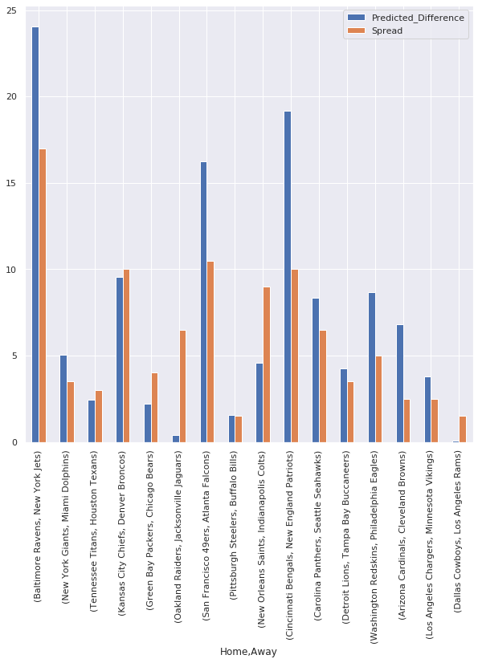

```python
sns.set()  # use Seaborn styles
bar_chart = upcoming_week_predictions.set_index(['Home', 'Away'])[['Predicted_Difference', 'Spread']].plot.bar(figsize=(10,10))
```

I compare predicted team totals to O/U in a bar chart - anywhere there is a large disparity between predicted total and O/U could be a good game to bet either the Over (if the predicted total blue line is largely above the O/U orange line) or Under (if the predicted total blue line is clearly below the O/U orange line).

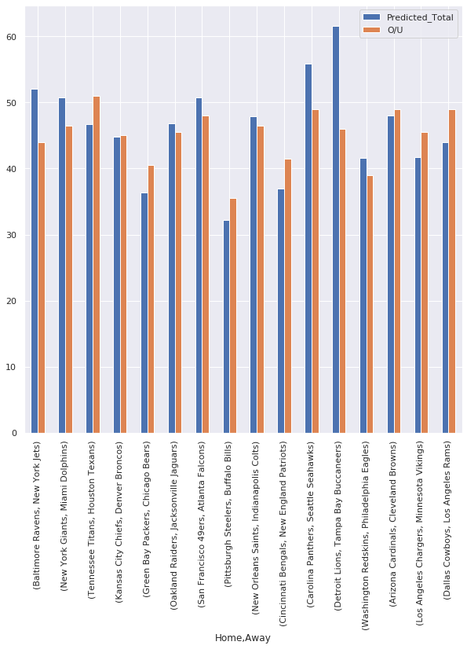

```python
upcoming_week_predictions['O/U'] = pd.to_numeric(upcoming_week_predictions['O/U'])
bar_chart = upcoming_week_predictions.set_index(['Home', 'Away'])[['Predicted_Total', 'O/U']].plot.bar(figsize=(10,10))
```

**MIGHT BE DIFFERENT INFORMATION IF YOU ARE RUNNING THE NOTEBOOK TO PREDICT GAMES AFTER WEEK 15**

## 6. Analyze Team Data to Verify Bets

To verify certain bets, it is helpful to look at average team data to confirm the predictive model.

```python
result_pivot = pd.pivot_table(result, values=['Offense', 'Defense'], index=['team', 'Roof Type'], aggfunc=np.nanmean)
result_pivot.head(60)
```

| team | Roof Type | Defense | Offense |
| --- | --- | --- | --- |
| Arizona Cardinals | Fixed | 31.000000 | 9.000000 |
|  | Open | 26.600000 | 24.600000 |
|  | Retractable | 30.000000 | 20.000000 |
| Atlanta Falcons | Fixed | 18.500000 | 19.000000 |
|  | Open | 3.000000 | 29.000000 |
|  | Retractable | 30.300000 | 23.300000 |
| Baltimore Ravens | Open | 18.153846 | 33.076923 |
| Buffalo Bills | Open | 16.416667 | 20.666667 |
|  | Retractable | 15.000000 | 26.000000 |
| Carolina Panthers | Fixed | 34.000000 | 31.000000 |
|  | Open | 28.444444 | 21.666667 |
|  | Retractable | 23.333333 | 24.666667 |
| Chicago Bears | Fixed | 20.000000 | 24.000000 |
|  | Open | 17.666667 | 18.250000 |
| Cincinnati Bengals | Open | 25.000000 | 15.230769 |
| Cleveland Browns | Open | 22.384615 | 21.000000 |
| Dallas Cowboys | Fixed | 19.500000 | 22.500000 |
|  | Open | 21.400000 | 24.600000 |
|  | Retractable | 20.166667 | 27.666667 |
| Denver Broncos | Fixed | 27.000000 | 23.000000 |
|  | Open | 19.500000 | 16.200000 |
|  | Retractable | 19.500000 | 25.500000 |
| Detroit Lions | Fixed | 27.285714 | 22.571429 |
|  | Open | 23.400000 | 20.400000 |
|  | Retractable | 27.000000 | 27.000000 |
| Green Bay Packers | Open | 20.500000 | 22.916667 |
|  | Retractable | 24.000000 | 34.000000 |
| Houston Texans | Fixed | 30.000000 | 28.000000 |
|  | Open | 22.000000 | 22.750000 |
|  | Retractable | 23.875000 | 24.750000 |
| Indianapolis Colts | Open | 24.800000 | 24.200000 |
|  | Retractable | 21.375000 | 21.875000 |
| Jacksonville Jaguars | Open | 26.454545 | 18.636364 |
|  | Retractable | 23.000000 | 12.500000 |
| Kansas City Chiefs | Fixed | 30.000000 | 34.000000 |
|  | Open | 20.916667 | 28.083333 |
| Los Angeles Chargers | Fixed | 13.000000 | 10.000000 |
|  | Open | 19.833333 | 23.250000 |
| Los Angeles Rams | Open | 22.272727 | 21.818182 |
|  | Retractable | 8.500000 | 35.500000 |
| Miami Dolphins | Open | 32.363636 | 18.090909 |
|  | Retractable | 21.500000 | 11.000000 |
| Minnesota Vikings | Fixed | 16.428571 | 29.714286 |
|  | Open | 22.000000 | 20.600000 |
|  | Retractable | 24.000000 | 28.000000 |
| New England Patriots | Open | 11.666667 | 26.333333 |
|  | Retractable | 28.000000 | 22.000000 |
| New Orleans Saints | Fixed | 25.142857 | 27.571429 |
|  | Open | 20.400000 | 25.000000 |
|  | Retractable | 18.000000 | 26.000000 |
| New York Giants | Fixed | 31.000000 | 26.000000 |
|  | Open | 26.909091 | 18.545455 |
|  | Retractable | 35.000000 | 17.000000 |
| New York Jets | Open | 23.153846 | 17.384615 |
| Oakland Raiders | Fixed | 34.000000 | 14.000000 |
|  | Open | 28.100000 | 18.900000 |
|  | Retractable | 25.500000 | 27.500000 |
| Philadelphia Eagles | Fixed | 38.000000 | 20.000000 |
|  | Open | 20.200000 | 24.700000 |
|  | Retractable | 30.500000 | 15.000000 |

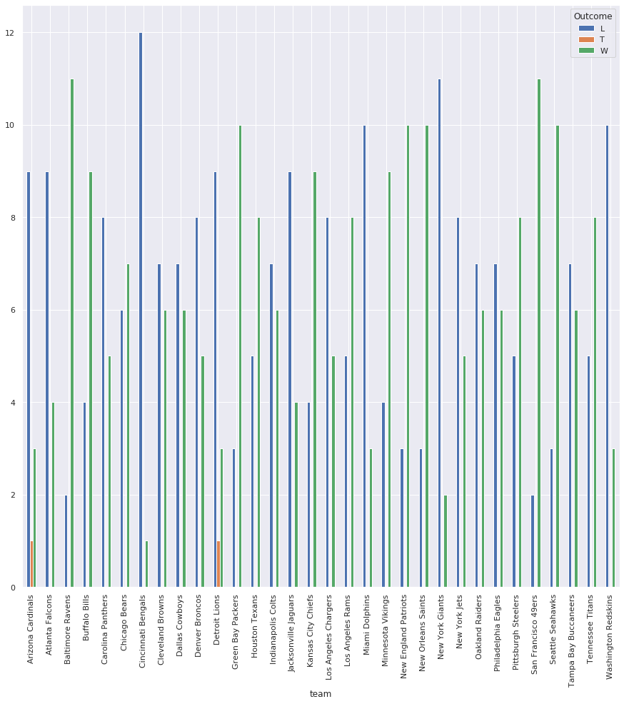

```python
sns.set()  # use Seaborn styles
records = pd.pivot_table(result, values = 'OPP', index='team', columns='Outcome', aggfunc='count')
records.plot.bar(figsize=(15,15))
```

BAL has won 11 games and the NYJ have won only 5.

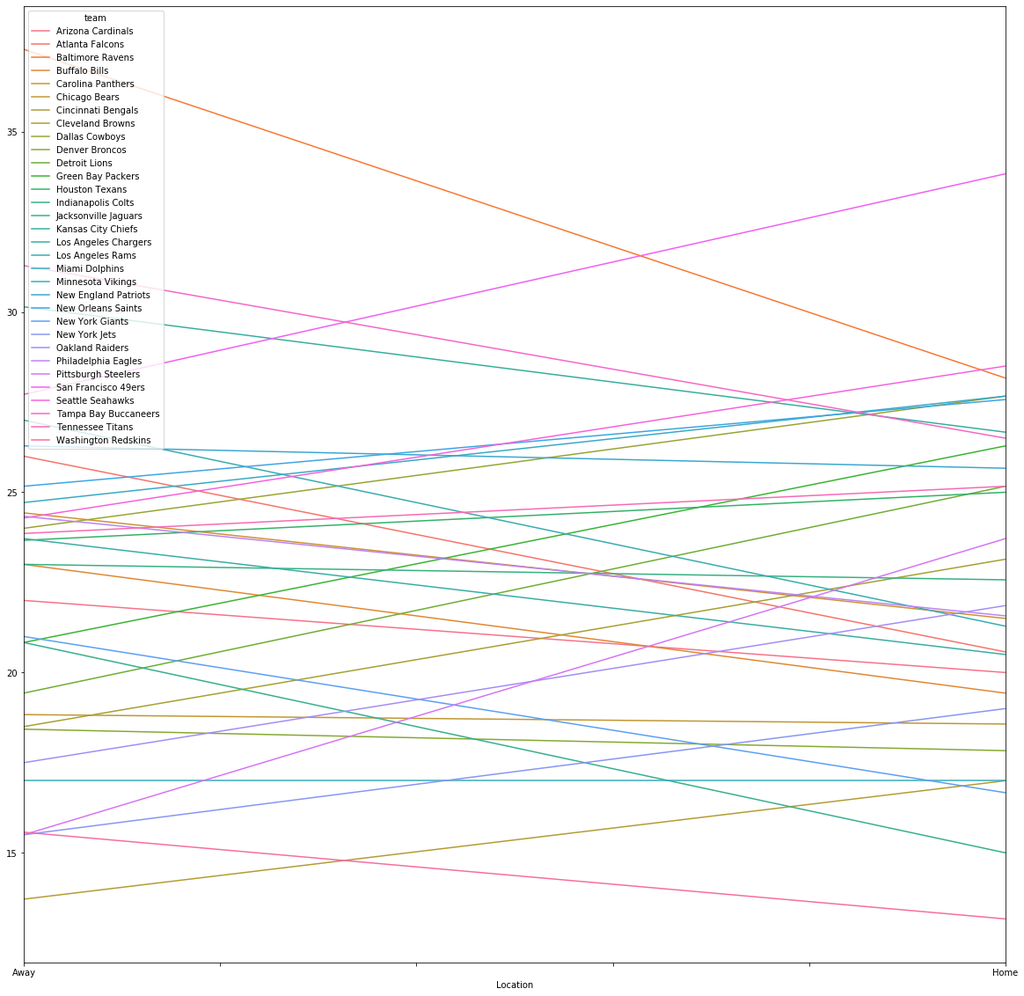

```python
NUM_COLORS = 32

sns.reset_orig()  # get default matplotlib styles back
clrs = sns.color_palette('husl', n_colors=NUM_COLORS)  # a list of RGB tuples
scores_by_location = result.pivot_table('Offense', index='Location', columns='team', aggfunc='mean').plot(figsize=(20, 20), color=clrs)

plt.show()
plt. savefig('avgScoreByLocation.png')
```

BAL scores more point away than home but still scores around 29 points at home.

**Author:** Caroline Gilhool, University of Michigan, December 12, 2019